# Part II - Ford GoBike System Data

## by Yasmin Madjitey

## Investigation Overview

> In this data exploration project, I decided to go with the Ford GoBike System because I find the bike-sharing system in general, interesting. It is an opportunity to look at the state of the system in general using the provided dataset as an example. I looked at what could influence the bike-sharing system. Could it be distance, time, or user type? As in when are most trips taken in terms of time of day or day of the week? How long does a trip take? Does the above depend on if a user is a subscriber or customer?

> Using univariate, bivariate and multivariate exploration, I looked at the cases mentioned above in detail.

## Dataset Overview

> The dataset consists of 183,412 entries in the dataset with 16 original columns/attributes in relation to individual rides made in the bike-sharing system. However, for better understanding, I extracted the days in which the service was started and ended into new columns. Some of the features include the duration of the ride, user type, members birth year, etc. The dataset covers entries for the month of February. Due some quality issues and inconsistencies in the dataset, the dataset was cleaned for analysis. The appropriate data types were assigned, inconsistent values were handled and new columns such as a distance column, calculated based on the provided latitude and longitude, was added to the dataset. The final dataset consists of more object variables than numeric ones.

## (Visualization 1)

> When are most trips taken in terms of time of day or day of the week?

The distributions above show that trips occured within a 24 hour time frame. Both diagrams for start and end days look the same with the most trips ocurring on Thursdays. Also, most trips start from 8:00 and 17:00 and most trips end around the same hour.

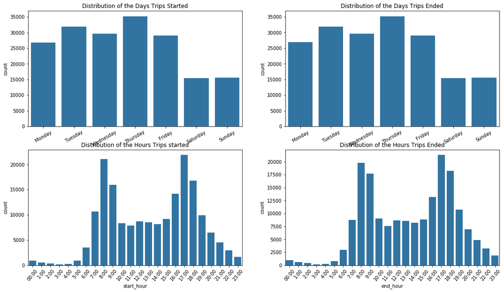

## (Visualization 2)

> How long does a trip take?

> In this section, I investigated the relationships between pairs of the above mentioned variables in the data. Visualizing the relationship between the duration and distance covered, one would expect the distance covered by a trip to be in tune with the duration. The bulk of the data sat around 0-10 hours and 0-20 km. It can also be seen that, an increase in the trip duration does not neccessarily corespond with an increase in distance covered. This could be as a result of stops or pauses taken by the individual rider.

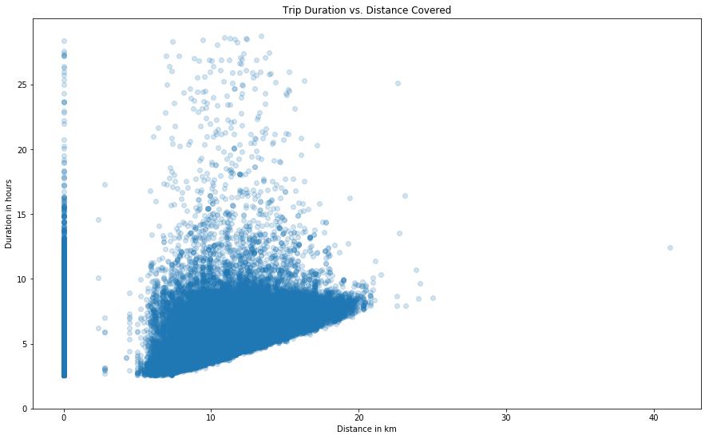

## (Visualization 3)

> Does the trip distance and duration depend on if a user is a subscriber or customer?

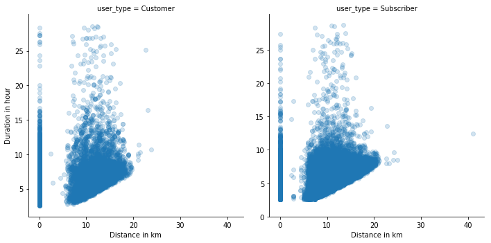

[output not shown]